# Intro to R by Data & Visualization Services

Joel Herndon & John Little

2017-08-01

# Intro to R

## Housekeeping (Joel)

#### Overview PPT

1. Welcome
2. What is r
3. What is [RStudio](https://www.rstudio.com/)
4. What is a Project
5. What is [Docker](https://vm-manage.oit.duke.edu/containers/rstudio)

```r
library(tidyverse)
library(ggvis)
```

## Data Management (John)

- We’ll use a derivitive of the `mtcars` dataset.
- Use the `?mtcars` to get the codebook.

### Load Data

RStudio has an on-board data loading wizard which uses the `readr()` package for data loading.  
See Menubar `File > Import Dataset`

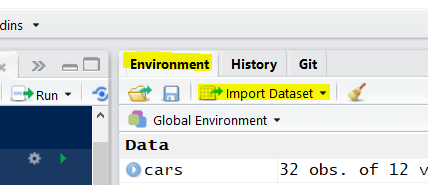

> RStudio Environment Pane

```r
# readr::read_csv
# 'read_csv()' is part of the 'readr' package and will override the base-R default of converting characters as factors.  https://cran.r-project.org/web/packages/readr/README.html
cars <- read_csv("data/cars.csv")
```

### View your data in a grid

```r
View(cars)
# Displays as a tab in the source-pane quadrant
# Does not dipsplay in an R Notebooks
```

#### Other Data Loaders, a selective list

- `View()` is an exploratory convenience; it’s not “reproducible” in the sense of generating a report or leaving a trail of your work. One of the advantages is on-board clickable sorting
- Environment Pane has information about data objects

### Modern Data Frames: Tibbles

- “Table as data frame”“, a modern tidyverse table

```r
cars
```

| mpg | cyl | disp | hp | drat | wt | qsec | vs | am | gear | carb | makeModel |
| --- | --- | --- | --- | --- | --- | --- | --- | --- | --- | --- | --- |
| 21.0 | 6 | 160.0 | 110 | 3.90 | 2.620 | 16.46 | 0 | 1 | 4 | 4 | Mazda RX4 |
| 21.0 | 6 | 160.0 | 110 | 3.90 | 2.875 | 17.02 | 0 | 1 | 4 | 4 | Mazda RX4 Wag |
| 22.8 | 4 | 108.0 | 93 | 3.85 | 2.320 | 18.61 | 1 | 1 | 4 | 1 | Datsun 710 |
| 21.4 | 6 | 258.0 | 110 | 3.08 | 3.215 | 19.44 | 1 | 0 | 3 | 1 | Hornet 4 Drive |
| 18.7 | 8 | 360.0 | 175 | 3.15 | 3.440 | 17.02 | 0 | 0 | 3 | 2 | Hornet Sportabout |
| 18.1 | 6 | 225.0 | 105 | 2.76 | 3.460 | 20.22 | 1 | 0 | 3 | 1 | Valiant |
| 14.3 | 8 | 360.0 | 245 | 3.21 | 3.570 | 15.84 | 0 | 0 | 3 | 4 | Duster 360 |
| 24.4 | 4 | 146.7 | 62 | 3.69 | 3.190 | 20.00 | 1 | 0 | 4 | 2 | Merc 240D |
| 22.8 | 4 | 140.8 | 95 | 3.92 | 3.150 | 22.90 | 1 | 0 | 4 | 2 | Merc 230 |
| 19.2 | 6 | 167.6 | 123 | 3.92 | 3.440 | 18.30 | 1 | 0 | 4 | 4 | Merc 280 |

[output cut: 22 more lines]

### Data Structure

#### Class

```r
class(cars)
```

```
[1] "tbl_df"     "tbl"        "data.frame"
```

#### Glimpse into a data frame

```r
glimpse(cars)
```

```
Observations: 32
Variables: 12
$ mpg       <dbl> 21.0, 21.0, 22.8, 21.4, 18.7...
$ cyl       <dbl> 6, 6, 4, 6, 8, 6, 8, 4, 4, 6...
$ disp      <dbl> 160.0, 160.0, 108.0, 258.0, ...
$ hp        <dbl> 110, 110, 93, 110, 175, 105,...
$ drat      <dbl> 3.90, 3.90, 3.85, 3.08, 3.15...
$ wt        <dbl> 2.620, 2.875, 2.320, 3.215, ...
$ qsec      <dbl> 16.46, 17.02, 18.61, 19.44, ...
$ vs        <dbl> 0, 0, 1, 1, 0, 1, 0, 1, 1, 1...
$ am        <dbl> 1, 1, 1, 0, 0, 0, 0, 0, 0, 0...
$ gear      <dbl> 4, 4, 4, 3, 3, 3, 3, 4, 4, 4...
$ carb      <dbl> 4, 4, 1, 1, 2, 1, 4, 2, 2, 4...
$ makeModel <chr> "Mazda RX4", "Mazda RX4 Wag"...
```

#### Older style

`str()` works on all data structures: data frames, matricies, lists, etc.

```r
str(cars)
```

```
Classes ‘tbl_df’, ‘tbl’ and 'data.frame':   32 obs. of  12 variables:
 $ mpg      : num  21 21 22.8 21.4 18.7 18.1 14.3 24.4 22.8 19.2 ...
 $ cyl      : num  6 6 4 6 8 6 8 4 4 6 ...
 $ disp     : num  160 160 108 258 360 ...
 $ hp       : num  110 110 93 110 175 105 245 62 95 123 ...
 $ drat     : num  3.9 3.9 3.85 3.08 3.15 2.76 3.21 3.69 3.92 3.92 ...
 $ wt       : num  2.62 2.88 2.32 3.21 3.44 ...
 $ qsec     : num  16.5 17 18.6 19.4 17 ...
 $ vs       : num  0 0 1 1 0 1 0 1 1 1 ...
 $ am       : num  1 1 1 0 0 0 0 0 0 0 ...
 $ gear     : num  4 4 4 3 3 3 3 4 4 4 ...
 $ carb     : num  4 4 1 1 2 1 4 2 2 4 ...
 $ makeModel: chr  "Mazda RX4" "Mazda RX4 Wag" "Datsun 710" "Hornet 4 Drive" ...
 - attr(*, "spec")=List of 2
  ..$ cols   :List of 12
  .. ..$ mpg      : list()
  .. .. ..- attr(*, "class")= chr  "collector_double" "collector"
  .. ..$ cyl      : list()
  .. .. ..- attr(*, "class")= chr  "collector_double" "collector"
  .. ..$ disp     : list()
  .. .. ..- attr(*, "class")= chr  "collector_double" "collector"
  .. ..$ hp       : list()
  .. .. ..- attr(*, "class")= chr  "collector_double" "collector"
  .. ..$ drat     : list()
  .. .. ..- attr(*, "class")= chr  "collector_double" "collector"
  .. ..$ wt       : list()
  .. .. ..- attr(*, "class")= chr  "collector_double" "collector"
  .. ..$ qsec     : list()
  .. .. ..- attr(*, "class")= chr  "collector_double" "collector"
  .. ..$ vs       : list()
  .. .. ..- attr(*, "class")= chr  "collector_double" "collector"
  .. ..$ am       : list()
  .. .. ..- attr(*, "class")= chr  "collector_double" "collector"
  .. ..$ gear     : list()
  .. .. ..- attr(*, "class")= chr  "collector_double" "collector"
  .. ..$ carb     : list()
  .. .. ..- attr(*, "class")= chr  "collector_double" "collector"
  .. ..$ makeModel: list()
  .. .. ..- attr(*, "class")= chr  "collector_character" "collector"
  ..$ default: list()
  .. ..- attr(*, "class")= chr  "collector_guess" "collector"
  ..- attr(*, "class")= chr "col_spec"
```

#### Useful Command

`tbl_vars` lists table variables (column headers) as a vector

```r
tbl_vars(cars)
```

```
 [1] "mpg"       "cyl"       "disp"
 [4] "hp"        "drat"      "wt"
 [7] "qsec"      "vs"        "am"
[10] "gear"      "carb"      "makeModel"
```

## EXERCISE, Part One: Loading Data (Joel)

1. Take the [Quiz](https://libjohn.shinyapps.io/intro2r-assignments2/)
2. Hands-on (in an R file): File > Open File > Student_Assignments.Rmd (Part One)

## Data Reshaping - dplyr (John)

**dplyr** is a widely adopted r package, part of tidyverse, which uses **five English verbs** to reshape data

### Arrange

**Arrange** to sort rows by column

```r
cars %>%
  arrange(cyl, desc(mpg), desc(hp))
```

| mpg | cyl | disp | hp | drat | wt | qsec | vs | am | gear | carb | makeModel |
| --- | --- | --- | --- | --- | --- | --- | --- | --- | --- | --- | --- |
| 33.9 | 4 | 71.1 | 65 | 4.22 | 1.835 | 19.90 | 1 | 1 | 4 | 1 | Toyota Corolla |
| 32.4 | 4 | 78.7 | 66 | 4.08 | 2.200 | 19.47 | 1 | 1 | 4 | 1 | Fiat 128 |
| 30.4 | 4 | 95.1 | 113 | 3.77 | 1.513 | 16.90 | 1 | 1 | 5 | 2 | Lotus Europa |
| 30.4 | 4 | 75.7 | 52 | 4.93 | 1.615 | 18.52 | 1 | 1 | 4 | 2 | Honda Civic |
| 27.3 | 4 | 79.0 | 66 | 4.08 | 1.935 | 18.90 | 1 | 1 | 4 | 1 | Fiat X1-9 |
| 26.0 | 4 | 120.3 | 91 | 4.43 | 2.140 | 16.70 | 0 | 1 | 5 | 2 | Porsche 914-2 |
| 24.4 | 4 | 146.7 | 62 | 3.69 | 3.190 | 20.00 | 1 | 0 | 4 | 2 | Merc 240D |
| 22.8 | 4 | 140.8 | 95 | 3.92 | 3.150 | 22.90 | 1 | 0 | 4 | 2 | Merc 230 |
| 22.8 | 4 | 108.0 | 93 | 3.85 | 2.320 | 18.61 | 1 | 1 | 4 | 1 | Datsun 710 |
| 21.5 | 4 | 120.1 | 97 | 3.70 | 2.465 | 20.01 | 1 | 0 | 3 | 1 | Toyota Corona |

[output cut: 22 more lines]

### Select

**Select** to choose columns (variables)

```r
cars %>%
    arrange(cyl, desc(mpg), desc(hp)) %>%
    select(makeModel, cyl, mpg, hp)
```

| makeModel | cyl | mpg | hp |
| --- | --- | --- | --- |
| Toyota Corolla | 4 | 33.9 | 65 |
| Fiat 128 | 4 | 32.4 | 66 |
| Lotus Europa | 4 | 30.4 | 113 |
| Honda Civic | 4 | 30.4 | 52 |
| Fiat X1-9 | 4 | 27.3 | 66 |
| Porsche 914-2 | 4 | 26.0 | 91 |
| Merc 240D | 4 | 24.4 | 62 |
| Merc 230 | 4 | 22.8 | 95 |
| Datsun 710 | 4 | 22.8 | 93 |
| Toyota Corona | 4 | 21.5 | 97 |

[output cut: 22 more lines]

### Filter

**Filter** to select rows

```r
sixcyls <- cars %>%
  filter(cyl == 6)
sixcyls    # display filtered data frame
```

| mpg | cyl | disp | hp | drat | wt | qsec | vs | am | gear | carb | makeModel |
| --- | --- | --- | --- | --- | --- | --- | --- | --- | --- | --- | --- |
| 21.0 | 6 | 160.0 | 110 | 3.90 | 2.620 | 16.46 | 0 | 1 | 4 | 4 | Mazda RX4 |
| 21.0 | 6 | 160.0 | 110 | 3.90 | 2.875 | 17.02 | 0 | 1 | 4 | 4 | Mazda RX4 Wag |
| 21.4 | 6 | 258.0 | 110 | 3.08 | 3.215 | 19.44 | 1 | 0 | 3 | 1 | Hornet 4 Drive |
| 18.1 | 6 | 225.0 | 105 | 2.76 | 3.460 | 20.22 | 1 | 0 | 3 | 1 | Valiant |
| 19.2 | 6 | 167.6 | 123 | 3.92 | 3.440 | 18.30 | 1 | 0 | 4 | 4 | Merc 280 |
| 17.8 | 6 | 167.6 | 123 | 3.92 | 3.440 | 18.90 | 1 | 0 | 4 | 4 | Merc 280C |
| 19.7 | 6 | 145.0 | 175 | 3.62 | 2.770 | 15.50 | 0 | 1 | 5 | 6 | Ferrari Dino |

### Mutate

**Mutate** to create new variables (add columns)

```r
sixcyls %>%
  mutate(dispWt = disp / wt) %>%
  select(makeModel, cyl, mpg, hp, dispWt)
```

| makeModel | cyl | mpg | hp | dispWt |
| --- | --- | --- | --- | --- |
| Mazda RX4 | 6 | 21.0 | 110 | 61.06870 |
| Mazda RX4 Wag | 6 | 21.0 | 110 | 55.65217 |
| Hornet 4 Drive | 6 | 21.4 | 110 | 80.24883 |
| Valiant | 6 | 18.1 | 105 | 65.02890 |
| Merc 280 | 6 | 19.2 | 123 | 48.72093 |
| Merc 280C | 6 | 17.8 | 123 | 48.72093 |
| Ferrari Dino | 6 | 19.7 | 175 | 52.34657 |

### Count

**Count** to summarize observations (or rows)

```r
sixcyls %>%
  count(hp)
```

| hp | n |
| --- | --- |
| 105 | 1 |
| 110 | 3 |
| 123 | 2 |
| 175 | 1 |

### Summarize

Summarize to collapse values into a summary

```r
sixcyls %>%
  group_by(hp) %>%
  summarize(Count = n())
```

| hp | Count |
| --- | --- |
| 105 | 1 |
| 110 | 3 |
| 123 | 2 |
| 175 | 1 |

### Put it all together

```r
cars %>%
  filter(cyl >= 4, cyl <= 6) %>%
  select(makeModel, mpg:wt) %>%
  mutate(dispWt = disp / wt) %>%
  arrange(desc(mpg), wt)
```

| makeModel | mpg | cyl | disp | hp | drat | wt | dispWt |
| --- | --- | --- | --- | --- | --- | --- | --- |
| Toyota Corolla | 33.9 | 4 | 71.1 | 65 | 4.22 | 1.835 | 38.74659 |
| Fiat 128 | 32.4 | 4 | 78.7 | 66 | 4.08 | 2.200 | 35.77273 |
| Lotus Europa | 30.4 | 4 | 95.1 | 113 | 3.77 | 1.513 | 62.85525 |
| Honda Civic | 30.4 | 4 | 75.7 | 52 | 4.93 | 1.615 | 46.87307 |
| Fiat X1-9 | 27.3 | 4 | 79.0 | 66 | 4.08 | 1.935 | 40.82687 |
| Porsche 914-2 | 26.0 | 4 | 120.3 | 91 | 4.43 | 2.140 | 56.21495 |
| Merc 240D | 24.4 | 4 | 146.7 | 62 | 3.69 | 3.190 | 45.98746 |
| Datsun 710 | 22.8 | 4 | 108.0 | 93 | 3.85 | 2.320 | 46.55172 |
| Merc 230 | 22.8 | 4 | 140.8 | 95 | 3.92 | 3.150 | 44.69841 |
| Toyota Corona | 21.5 | 4 | 120.1 | 97 | 3.70 | 2.465 | 48.72211 |

[output cut: 8 more lines]

## EXERCISE, Part 2 (Joel)

2. Student_Assignments.Rmd::PART TWO **Data Management**
3. `arrange()`
4. `filter()`
5. `mutate()`
6. `select()`
7. `count()`

## Visualization with ggvis (John)

When in the data exploratory phase, you can quickly generate very basic visualizations with minimal effort. Your visualizations then appear in the Viewer Pane.

### Scatter Plot

Linear model and 95% confidence interval

```r
cars %>%
  ggvis(~wt, ~mpg) %>%
  layer_points() %>%
  layer_model_predictions(model = "lm", se=TRUE)
```

```
Guessing formula = mpg ~ wt
```

[More information on ggvis scatterplots](http://ggvis.rstudio.com/cookbook.html#scatterplots)

### Bar Graph

```r
cars %>%
  mutate(cyl = factor(cyl, labels = c("four","six","eight"))) %>%
  ggvis(~cyl) %>%
  layer_bars()
```

[More information on ggvis bar graphs](http://ggvis.rstudio.com/cookbook.html#bar-graphs)

### Histogram

```r
cars %>%
  ggvis(~mpg) %>%
  layer_histograms()
```

[More information on ggvis histograms](http://ggvis.rstudio.com/cookbook.html#histograms)

### Line graph

```r
cars %>%
  ggvis( ~wt, ~mpg) %>%
  group_by(cyl) %>%
  layer_lines(stroke = ~factor(cyl)) %>%
  layer_points(~wt, ~mpg, stroke := "black", fill = ~factor(cyl))
```

[More information on line graphs](http://ggvis.rstudio.com/cookbook.html#line-graphs)

```r
cars %>%
  ggvis(~wt, ~mpg) %>%
  group_by(cyl) %>%
  layer_model_predictions(model="lm", se = TRUE) %>%
  layer_points(~wt, ~mpg, stroke := "black", fill = ~factor(cyl), size := ~hp, opacity := 0.7)
```

#### Shareable under CC BY-NC license

Data, presentation, and handouts are shareable under [CC BY-NC license](https://creativecommons.org/licenses/by-nc/4.0/)